# Strategies for improving MCMC

NIMBLE 2022 Lisbon Workshop

NIMBLE Development Team

June 2022

# Overview

Some strategies for improving MCMC

- Customize sampler choices. For example:
  - Try sampling standard deviations on a log scale [already seen].
  - Try slice samplers instead of Metropolis-Hastings [already seen].
  - Try blocking correlated parameters [already seen; more here]
  - Try multiple samplers for slow-mixing parameters [not shown].
- Reparameterize. For example:
  - Center covariates [already seen]
  - Centered versus non-centered random effects parameterization
  - Rotated coordinates to reduce posterior correlation [already seen; more here]
- Rewrite the model. For example:
  - Rewrite the model to reduce dependencies
  - Vectorize declarations to improve computational efficiency
  - Marginalize to remove parameters
- (Advanced) Write new samplers that take advantage of particular model structures [Module 10]

# Load the E. cervi example for later:

```r
source(file.path("..", "examples", "DeerEcervi", "load_DeerEcervi.R"),
       chdir = TRUE)
```

# Sampler choices

Sampler choices:

- Sampling standard deviations on the log scale can help, especially when there is posterior support near 0.
- Slice sampling can help mix a parameter at some computational cost.
- Blocking can help when parameters are correlated *given other parameters*.
  - If parameters are *marginally correlated* but *conditionally independent*, blocking will not help.
  - This occurs if parameters are marginally correlated only because they both depend on something else.
- Model-specific understanding can yield good sampling strategies.

# Centering covariates or random effects

Centering refers to two issues:

- Centering of covariates as they are provided for the analysis.
  - Think of $y_i = \beta_0 + \beta_1 x_i + \epsilon_i$.
  - If the $x_i$ are not centered, then considering $\beta_1 \rightarrow \beta_1'$ is also like adding $(\beta_1' - \beta_1) \bar{x}$ to the intercept.
  - A standard result in linear regression is that estimates of $\beta_0$ and $\beta_1$ are correlated.
  - Centering $x_i$ around its mean removes the posterior correlation between $\beta_0$ and $\beta_1$.
  - In our example, we centered `Length`, but not separately for each sex.
- Random effects with a mean of zero (non-centered parameterization) versus centered around a mean (centered parameterization).
  - E.g., `farm_effect ~ N(0, sd)` vs. `farm_effect ~ N(mean, sd)`.
  - Theory shows either parameterization can be better, depending on the model and data, but with reasonable amount of data, centered is often better.
  - However, for HMC, as in Stan, uncentered is generally better!

# Back to the E. cervi MCMC

We’ll explore centering a covariate and the centered random effects parameterization here.

Four sets of model/MCMC configuration:

1. Original setting from last unit – centered length covariate
2. Center the random effects (still centering length covariate): “ctrRE”
3. Uncentered length covariate: “uncLen”
4. Uncentered length covariate and block intercept/slope pairs: “block”

# 1.) E. cervi original MCMC

Let’s take a deeper look at the mixing of our basic MCMC for the E. cervi example (where the ‘length’ variable is centered).

```r
set.seed(123)
model <- nimbleModel(DEcode, constants = DEconstants, inits = DEinits_vals, data = DEdata)
```

```
## Defining model
```

```
## Building model
```

```
## Setting data and initial values
```

```
## Running calculate on model
##   [Note] Any error reports that follow may simply reflect missing values in model variables.
```

```
## Checking model sizes and dimensions
```

```r
cmodel <- compileNimble(model)
```

```
## Compiling
##   [Note] This may take a minute.
##   [Note] Use 'showCompilerOutput = TRUE' to see C++ compilation details.
```

```r
mcmcConf <- configureMCMC(model)
```

```
## ===== Monitors =====
## thin = 1: farm_sd, length_coef, sex_int
## ===== Samplers =====
## RW sampler (29)
##   - sex_int[]  (2 elements)
##   - length_coef[]  (2 elements)
##   - farm_sd
##   - farm_effect[]  (24 elements)
```

```r
mcmcConf$addMonitors('farm_effect')
```

```
## thin = 1: farm_effect, farm_sd, length_coef, sex_int
```

```r
mcmc <- buildMCMC(mcmcConf)
cmcmc <- compileNimble(mcmc, project = model)
```

```
## Compiling
##   [Note] This may take a minute.
##   [Note] Use 'showCompilerOutput = TRUE' to see C++ compilation details.
```

```r
system.time(DEsamples <- runMCMC(cmcmc, niter = 5000))
```

```
## Running chain 1 ...
```

```
## |-------------|-------------|-------------|-------------|
## |-------------------------------------------------------|
```

```
##    user  system elapsed
##   1.564   0.004   1.567
```

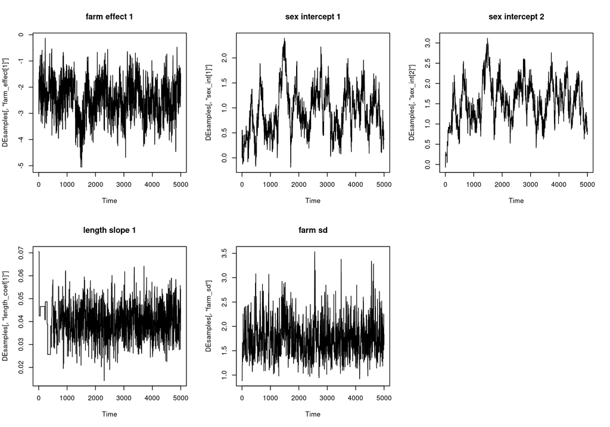

```r
# change to c(3,5) in live demo
par(mfrow = c(2,3))
ts.plot(DEsamples[ , 'farm_effect[1]'], main = 'farm effect 1')
ts.plot(DEsamples[ , 'sex_int[1]'], main = 'sex intercept 1')
ts.plot(DEsamples[ , 'sex_int[2]'], main = 'sex intercept 2')
ts.plot(DEsamples[ , 'length_coef[1]'], main = 'length slope 1')
ts.plot(DEsamples[ , 'farm_sd'], main = 'farm sd')
```

What’s not mixing? The intercepts (`sex_int[1:2]`) go up and down together and the farm effects inversely to them.

Why?

```
  logit(disease_probability[i]) <-
      sex_int[ sex[i] ] +
      length_coef[ sex[i] ]*length[i] +
      farm_effect[ farm_ids[i] ]
```

# 2) Center the random effects

Solution: center the random effects

Difficulty: there are two intercepts!

Secondary solution: have second intercept be an offset for sex 2 only

```r
DEcodeCtrRE <- nimbleCode({
  sex_int[2] ~ dnorm(0, sd = 1000)     # offset for sex 2
  sex_int[1] <- 0                      # replaced by 'mu'
  for(i in 1:2) {
    # Priors for ntercepts and length coefficients for sex = 1,2
    length_coef[i] ~ dnorm(0, sd = 1000)
  }

  # Priors for farm random effects and their standard deviation.
  farm_sd ~ dunif(0, 20)
  for(i in 1:num_farms) {
    farm_effect[i] ~ dnorm(mu, sd = farm_sd)  # centered random effects
  }
  mu ~ dnorm(0, sd = 100)

  # logit link and Bernoulli data probabilities
  for(i in 1:num_animals) {
    logit(disease_probability[i]) <-
      sex_int[ sex[i] ] +
      length_coef[ sex[i] ]*length[i] +
      farm_effect[ farm_ids[i] ]
    Ecervi_01[i] ~ dbern(disease_probability[i])
  }
})

set.seed(123)
modelCtrRE = nimbleModel(DEcodeCtrRE, constants = DEconstants, inits = c(DEinits_vals, mu = 0), data = DEdata)
```

```
## Defining model
```

```
## Building model
```

```
## Setting data and initial values
```

```
## Running calculate on model
##   [Note] Any error reports that follow may simply reflect missing values in model variables.
```

```
## Checking model sizes and dimensions
```

```r
cmodelCtrRE <- compileNimble(modelCtrRE)
```

```
## Compiling
##   [Note] This may take a minute.
##   [Note] Use 'showCompilerOutput = TRUE' to see C++ compilation details.
```

```r
mcmcConfCtrRE <- configureMCMC(modelCtrRE)
```

```
## ===== Monitors =====
## thin = 1: farm_sd, length_coef, mu, sex_int
## ===== Samplers =====
## RW sampler (28)
##   - sex_int[]  (1 element)
##   - length_coef[]  (2 elements)
##   - farm_sd
##   - farm_effect[]  (24 elements)
## conjugate sampler (1)
##   - mu
```

```r
mcmcConfCtrRE$addMonitors('farm_effect')
```

```
## thin = 1: farm_effect, farm_sd, length_coef, mu, sex_int
```

```r
mcmcCtrRE <- buildMCMC(mcmcConfCtrRE)
cmcmcCtrRE <- compileNimble(mcmcCtrRE, project = modelCtrRE)
```

```
## Compiling
##   [Note] This may take a minute.
##   [Note] Use 'showCompilerOutput = TRUE' to see C++ compilation details.
```

```r
system.time(DEsamplesCtrRE <- runMCMC(cmcmcCtrRE, niter = 5000))
```

```
## Running chain 1 ...
```

```
## |-------------|-------------|-------------|-------------|
## |-------------------------------------------------------|
```

```
##    user  system elapsed
##   1.020   0.004   1.024
```

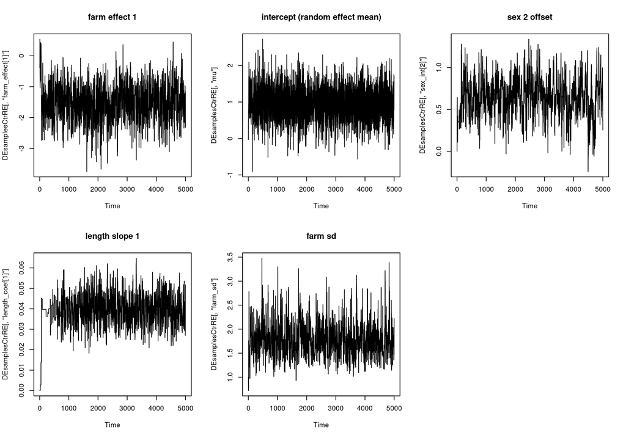

```r
par(mfrow = c(2,3))
ts.plot(DEsamplesCtrRE[ , 'farm_effect[1]'], main = 'farm effect 1')
ts.plot(DEsamplesCtrRE[ , 'mu'], main = 'intercept (random effect mean)')
ts.plot(DEsamplesCtrRE[ , 'sex_int[2]'], main = 'sex 2 offset')
ts.plot(DEsamplesCtrRE[ , 'length_coef[1]'], main = 'length slope 1')
ts.plot(DEsamplesCtrRE[ , 'farm_sd'], main = 'farm sd')
```

So that works pretty well.

# 3) Without centering the covariate

Let’s consider the original model, but without centering the covariate.

```r
DEconstants_uncLen <- DEconstants # Artificially un-center Length
DEconstants_uncLen$length <- DeerEcervi$Length

set.seed(123)
DEinits_vals_uncLen <- DEinits_vals
DEinits_vals_uncLen$sex_int <- c(-8, -8)

modelUncLen = nimbleModel(DEcode, constants = DEconstants_uncLen, inits = DEinits_vals_uncLen, data = DEdata)
```

```
## Defining model
```

```
## Building model
```

```
## Setting data and initial values
```

```
## Running calculate on model
##   [Note] Any error reports that follow may simply reflect missing values in model variables.
```

```
## Checking model sizes and dimensions
```

```r
cmodelUncLen <- compileNimble(modelUncLen)
```

```
## Compiling
##   [Note] This may take a minute.
##   [Note] Use 'showCompilerOutput = TRUE' to see C++ compilation details.
```

```r
mcmcConfUncLen <- configureMCMC(modelUncLen)
```

```
## ===== Monitors =====
## thin = 1: farm_sd, length_coef, sex_int
## ===== Samplers =====
## RW sampler (29)
##   - sex_int[]  (2 elements)
##   - length_coef[]  (2 elements)
##   - farm_sd
##   - farm_effect[]  (24 elements)
```

```r
mcmcConfUncLen$addMonitors('farm_effect')
```

```
## thin = 1: farm_effect, farm_sd, length_coef, sex_int
```

```r
mcmcUncLen <- buildMCMC(mcmcConfUncLen)
cmcmcUncLen <- compileNimble(mcmcUncLen, project = modelUncLen)
```

```
## Compiling
##   [Note] This may take a minute.
##   [Note] Use 'showCompilerOutput = TRUE' to see C++ compilation details.
```

```r
system.time(DEsamplesUncLen <- runMCMC(cmcmcUncLen, niter = 5000))
```

```
## Running chain 1 ...
```

```
## |-------------|-------------|-------------|-------------|
## |-------------------------------------------------------|
```

```
##    user  system elapsed
##   1.151   0.000   1.152
```

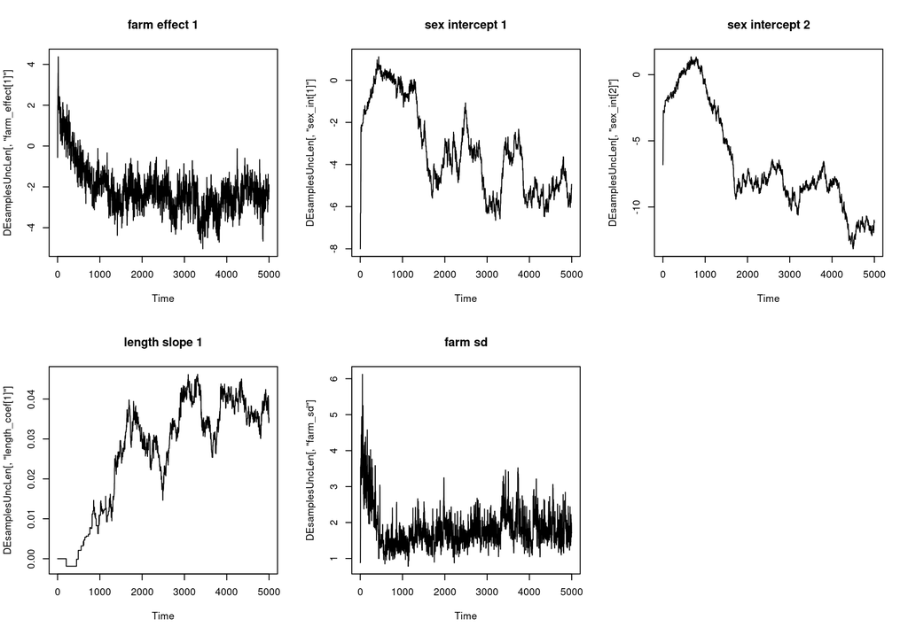

```r
par(mfrow = c(2,3))
ts.plot(DEsamplesUncLen[ , 'farm_effect[1]'], main = 'farm effect 1')
ts.plot(DEsamplesUncLen[ , 'sex_int[1]'], main = 'sex intercept 1')
ts.plot(DEsamplesUncLen[ , 'sex_int[2]'], main = 'sex intercept 2')
ts.plot(DEsamplesUncLen[ , 'length_coef[1]'], main = 'length slope 1')
ts.plot(DEsamplesUncLen[ , 'farm_sd'], main = 'farm sd')
```

So here the main issue is the correlation of the {intercept,slope} pairs.

# 4) Blocking

The standard answer for that problem is to block the parameters.

After some trial and error, it turns out that modifying the defaults for the block sampler helps a huge amount and turns it from performing poorly to performing very well. One aspect of this is getting the relative scales of the parameters about right.

```r
modelBlock = nimbleModel(DEcode, constants = DEconstants_uncLen, inits = DEinits_vals_uncLen, data = DEdata)
```

```
## Defining model
```

```
## Building model
```

```
## Setting data and initial values
```

```
## Running calculate on model
##   [Note] Any error reports that follow may simply reflect missing values in model variables.
```

```
## Checking model sizes and dimensions
```

```r
cmodelBlock <- compileNimble(modelBlock)
```

```
## Compiling
##   [Note] This may take a minute.
##   [Note] Use 'showCompilerOutput = TRUE' to see C++ compilation details.
```

```r
mcmcConfBlock <- configureMCMC(modelBlock)
```

```
## ===== Monitors =====
## thin = 1: farm_sd, length_coef, sex_int
## ===== Samplers =====
## RW sampler (29)
##   - sex_int[]  (2 elements)
##   - length_coef[]  (2 elements)
##   - farm_sd
##   - farm_effect[]  (24 elements)
```

```r
mcmcConfBlock$removeSamplers(c('sex_int','length_coef'))

# Add RW_block samplers, modifying adaptation behavior.
mcmcConfBlock$addSampler(target = c('sex_int[1]', 'length_coef[1]'),
                 type = "RW_block",
                 control = list(propCov = diag(c(.1, .01)), adaptInterval = 20,
                                adaptFactorExponent = 0.25))
```

```
##   [Note] Assigning an RW_block sampler to nodes with very different scales can result in low MCMC efficiency.  If all nodes assigned to RW_block are not on a similar scale, we recommend providing an informed value for the "propCov" control list argument, or using the AFSS sampler instead.
```

```r
mcmcConfBlock$addSampler(target = c('sex_int[2]', 'length_coef[2]'),
                 type = "RW_block",
                 control = list(propCov = diag(c(.1, .01)), adaptInterval = 20,
                                adaptFactorExponent = 0.25))
```

```
##   [Note] Assigning an RW_block sampler to nodes with very different scales can result in low MCMC efficiency.  If all nodes assigned to RW_block are not on a similar scale, we recommend providing an informed value for the "propCov" control list argument, or using the AFSS sampler instead.
```

```r
mcmcConfBlock$addMonitors('farm_effect')
```

```
## thin = 1: farm_effect, farm_sd, length_coef, sex_int
```

```r
mcmcBlock <- buildMCMC(mcmcConfBlock)
cmcmcBlock <- compileNimble(mcmcBlock, project = modelBlock)
```

```
## Compiling
##   [Note] This may take a minute.
##   [Note] Use 'showCompilerOutput = TRUE' to see C++ compilation details.
```

```r
system.time(DEsamplesBlock <- runMCMC(cmcmcBlock, niter = 5000))
```

```
## Running chain 1 ...
```

```
## |-------------|-------------|-------------|-------------|
## |-------------------------------------------------------|
```

```
##    user  system elapsed
##   0.808   0.000   0.808
```

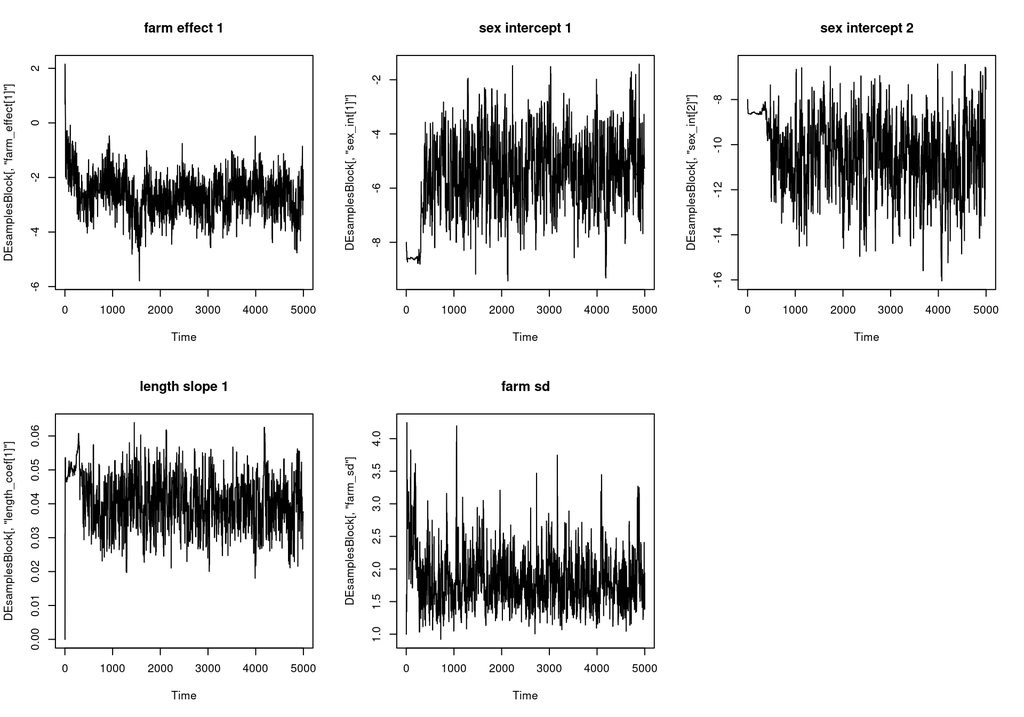

```r
par(mfrow = c(2,3))
ts.plot(DEsamplesBlock[ , 'farm_effect[1]'], main = 'farm effect 1')
ts.plot(DEsamplesBlock[ , 'sex_int[1]'], main = 'sex intercept 1')
ts.plot(DEsamplesBlock[ , 'sex_int[2]'], main = 'sex intercept 2')
ts.plot(DEsamplesBlock[ , 'length_coef[1]'], main = 'length slope 1')
ts.plot(DEsamplesBlock[ , 'farm_sd'], main = 'farm sd')
```

So the blocking helps a lot, though the farm effects show some oscillations. (A longer run looks fine.)

# Full comparison, accounting for sampling time

Traceplots and other diagnostics are useful for understanding but for a final decision between approaches we need to account for sampling time.

### Make `nimbleMCMCdefs`

```r
nimbleMCMCdefs = list(
  nimble_RWblock = function(model) { # Input should be a model
    mcmcConf <- configureMCMC(model)
    mcmcConf$removeSamplers(c('sex_int','length_coef'))
    mcmcConf$addSampler(target = c('sex_int[1]', 'length_coef[1]'),
                        type = "RW_block",
                        control = list(propCov = diag(c(.1, .01)), adaptInterval = 20,
                                       adaptFactorExponent = 0.25))
    mcmcConf$addSampler(target = c('sex_int[2]', 'length_coef[2]'),
                        type = "RW_block",
                        control = list(propCov = diag(c(.1, .01)), adaptInterval = 20,
                                       adaptFactorExponent = 0.25))
    mcmcConf                         # Output should be an MCMC configuration
  },
  nimble_AFSSblock = function(model) {
    mcmcConf <- configureMCMC(model)
    mcmcConf$removeSamplers(c('sex_int','length_coef'))
    mcmcConf$addSampler(target = c('sex_int[1]', 'length_coef[1]'),
                        type = "AF_slice",
                        control = list(sliceAdaptFactorInterval = 20))
    mcmcConf$addSampler(target = c('sex_int[2]', 'length_coef[2]'),
                        type = "AF_slice",
                        control = list(sliceAdaptFactorInterval = 20))
    mcmcConf                         # Output should be an MCMC configuration
  }
)
```

### Call `compareMCMCs` for the various NIMBLE cases

```r
set.seed(1)

mcmcResults_nimble_ctrRE <- compareMCMCs(
  modelInfo = list(code = DEcodeCtrRE,
                   data = DEdata,
                   constants = DEconstants,
                   inits = c(DEinits_vals, list(mu = 0))),
  ## monitors ## Use default monitors: top-level parameters
  MCMCs = c('nimble',
            'nimble_slice'),
  MCMCcontrol = list(niter = 50000, burnin = 5000)
)
```

```
## building nimble model...
```

```
## Defining model
```

```
## Building model
```

```
## Setting data and initial values
```

```
## Running calculate on model
##   [Note] Any error reports that follow may simply reflect missing values in model variables.
```

```
## Checking model sizes and dimensions
```

```
## ===== Monitors =====
## thin = 1: farm_sd, length_coef, mu, sex_int
## ===== Samplers =====
## RW sampler (28)
##   - sex_int[]  (1 element)
##   - length_coef[]  (2 elements)
##   - farm_sd
##   - farm_effect[]  (24 elements)
## conjugate sampler (1)
##   - mu
## ===== Monitors =====
## thin = 1: farm_sd, length_coef, mu, sex_int
## ===== Samplers =====
## slice sampler (29)
##   - sex_int[]  (1 element)
##   - length_coef[]  (2 elements)
##   - farm_sd
##   - mu
##   - farm_effect[]  (24 elements)
```

```
## Compiling
##   [Note] This may take a minute.
##   [Note] Use 'showCompilerOutput = TRUE' to see C++ compilation details.
```

```
## Compiling
##   [Note] This may take a minute.
##   [Note] Use 'showCompilerOutput = TRUE' to see C++ compilation details.
```

```
## |-------------|-------------|-------------|-------------|
## |-------------------------------------------------------|
## |-------------|-------------|-------------|-------------|
## |-------------------------------------------------------|
```

```r
mcmcResults_nimble_uncLen <- compareMCMCs(
  modelInfo = list(code = DEcode,
                   data = DEdata,
                   constants = DEconstants_uncLen,
                   inits = DEinits_vals_uncLen),
  ## monitors ## Use default monitors: top-level parameters
  MCMCs = c('nimble',
            'nimble_slice',
            'nimble_RWblock',    # Name matches nimbleMCMCdefs list name
            'nimble_AFSSblock'), # Ditto
  nimbleMCMCdefs = nimbleMCMCdefs,
  MCMCcontrol = list(niter = 50000, burnin = 5000)
)
```

```
## building nimble model...
```

```
## Defining model
```

```
## Building model
```

```
## Setting data and initial values
```

```
## Running calculate on model
##   [Note] Any error reports that follow may simply reflect missing values in model variables.
```

```
## Checking model sizes and dimensions
```

```
## ===== Monitors =====
## thin = 1: farm_sd, length_coef, sex_int
## ===== Samplers =====
## RW sampler (29)
##   - sex_int[]  (2 elements)
##   - length_coef[]  (2 elements)
##   - farm_sd
##   - farm_effect[]  (24 elements)
## ===== Monitors =====
## thin = 1: farm_sd, length_coef, sex_int
## ===== Samplers =====
## slice sampler (29)
##   - sex_int[]  (2 elements)
##   - length_coef[]  (2 elements)
##   - farm_sd
##   - farm_effect[]  (24 elements)
## ===== Monitors =====
## thin = 1: farm_sd, length_coef, sex_int
## ===== Samplers =====
## RW sampler (29)
##   - sex_int[]  (2 elements)
##   - length_coef[]  (2 elements)
##   - farm_sd
##   - farm_effect[]  (24 elements)
```

```
##   [Note] Assigning an RW_block sampler to nodes with very different scales can result in low MCMC efficiency.  If all nodes assigned to RW_block are not on a similar scale, we recommend providing an informed value for the "propCov" control list argument, or using the AFSS sampler instead.
```

```
##   [Note] Assigning an RW_block sampler to nodes with very different scales can result in low MCMC efficiency.  If all nodes assigned to RW_block are not on a similar scale, we recommend providing an informed value for the "propCov" control list argument, or using the AFSS sampler instead.
```

```
## ===== Monitors =====
## thin = 1: farm_sd, length_coef, sex_int
## ===== Samplers =====
## RW sampler (29)
##   - sex_int[]  (2 elements)
##   - length_coef[]  (2 elements)
##   - farm_sd
##   - farm_effect[]  (24 elements)
```

```
## Compiling
##   [Note] This may take a minute.
##   [Note] Use 'showCompilerOutput = TRUE' to see C++ compilation details.
```

```
## Compiling
##   [Note] This may take a minute.
##   [Note] Use 'showCompilerOutput = TRUE' to see C++ compilation details.
```

```
## |-------------|-------------|-------------|-------------|
## |-------------------------------------------------------|
## |-------------|-------------|-------------|-------------|
## |-------------------------------------------------------|
## |-------------|-------------|-------------|-------------|
## |-------------------------------------------------------|
## |-------------|-------------|-------------|-------------|
## |-------------------------------------------------------|
```

### Call `compareMCMCs` for JAGS (uncentered)

```r
mcmcResults_jags_uncLen <- compareMCMCs(
  modelInfo = list(code = DEcode_jags, # JAGS-compatible
                   data = DEdata,
                   constants = DEconstants_uncLen, # centered
                   inits = DEinits_vals_uncLen),
  ## monitors ## Use default monitors: top-level parameters
  MCMCs = c('jags'),
  MCMCcontrol = list(niter = 50000, burnin = 5000)
)
```

```
## building nimble model...
```

```
## Defining model
```

```
## Building model
```

```
## Setting data and initial values
```

```
## Running calculate on model
##   [Note] Any error reports that follow may simply reflect missing values in model variables.
```

```
## Checking model sizes and dimensions
```

### Combine and visualize results

```r
# Run this code to generate your own results
mcmcResults_ctrRE <- c(mcmcResults_nimble_ctrRE)
mcmcResults_uncLen <- c(mcmcResults_nimble_uncLen,
                 mcmcResults_jags_uncLen) ## These are lists of MCMCresult objects

make_MCMC_comparison_pages(mcmcResults_nimble_ctrRE,
                           modelName = "deer_ecervi_ctrRE_results")
make_MCMC_comparison_pages(mcmcResults_uncLen, modelName = "deer_ecervi_uncLen_results")
```

### Results

Results that come with these slides are here for uncentered length covariate and here for the centered random effects (and centered length covariate).

Results if you run the code yourself will be here for uncentered length covariate and here for the centered random effects (and centered length covariate).

# Think like a graph: reducing dependencies

Consider a basic state-space model.

Observation equation: $y_t \sim f(y_t | x_t)$. (Parameters are not shown.)

State equation: $x_t \sim g(x_t | x_{t-1})$

Two equivalent ways to write state-space models:

1. Process-noises are random variables. States are deterministic given process noises.

```r
code_heavy <- nimbleCode({
  for(t in 1:n)
    y[t] ~ dnorm(x[t], sd = sigma)
  for(t in 2:n) {
    x[t] <- x[t-1] + eps[t-1]
    eps[t] ~ dnorm(0, sd = omega)
  }
})
```

2. States are random variables.

```r
code_light <- nimbleCode({
  for(t in 1:n)
    y[t] ~ dnorm(x[t], sd = sigma)
  for(t in 2:n)
    x[t] ~ dnorm(x[t-1], sd = omega)
})
```

# Think like a graph: reducing dependencies (2)

```r
n <- 20
m_heavy <- nimbleModel(code_heavy,
                       data = list(y = rnorm(n)),
                       constants = list(n = n))
```

```
## Defining model
```

```
## Building model
```

```
## Setting data and initial values
```

```
## Running calculate on model
##   [Note] Any error reports that follow may simply reflect missing values in model variables.
```

```
## Checking model sizes and dimensions
```

```
##   [Note] This model is not fully initialized. This is not an error.
##          To see which variables are not initialized, use model$initializeInfo().
##          For more information on model initialization, see help(modelInitialization).
```

```r
m_light <- nimbleModel(code_light,
                       data = list(y = rnorm(n)),
                       constants = list(n = n))
```

```
## Defining model
```

```
## Building model
```

```
## Setting data and initial values
```

```
## Running calculate on model
##   [Note] Any error reports that follow may simply reflect missing values in model variables.
```

```
## Checking model sizes and dimensions
```

```
##   [Note] This model is not fully initialized. This is not an error.
##          To see which variables are not initialized, use model$initializeInfo().
##          For more information on model initialization, see help(modelInitialization).
```

What calculations are required to update `eps[18]` or `eps[1]` compared to `x[18]` or `x[1]`?

```r
m_heavy$getDependencies('eps[18]')
```

```
## [1] "eps[18]" "x[19]"   "y[19]"   "x[20]"   "y[20]"
```

```r
m_light$getDependencies('x[18]')
```

```
## [1] "x[18]" "y[18]" "x[19]"
```

```r
m_heavy$getDependencies('eps[1]')
```

```
##  [1] "x[2]"  "y[2]"  "x[3]"  "y[3]"  "x[4]"  "y[4]"  "x[5]"  "y[5]"  "x[6]"
## [10] "y[6]"  "x[7]"  "y[7]"  "x[8]"  "y[8]"  "x[9]"  "y[9]"  "x[10]" "y[10]"
## [19] "x[11]" "y[11]" "x[12]" "y[12]" "x[13]" "y[13]" "x[14]" "y[14]" "x[15]"
## [28] "y[15]" "x[16]" "y[16]" "x[17]" "y[17]" "x[18]" "y[18]" "x[19]" "y[19]"
## [37] "x[20]" "y[20]"
```

```r
m_light$getDependencies('x[1]')
```

```
## [1] "y[1]" "x[2]"
```

# Think like a graph: when to vectorize

Vectorizing some calculations:

- Can make code more compact.
- Can make model and MCMC building and compiling faster (fewer nodes).
- Can improve MCMC efficiency, but sometimes not by much (less looping over nodes).
- Can hurt MCMC efficiency if done in the wrong places (if unneeded dependencies are introduced).

```r
code <- nimbleCode({
  intercept ~ dnorm(0, sd = 1000)
  slope ~ dnorm(0, sd = 1000)
  sigma ~ dunif(0, 100)
  predicted.y[1:4] <- intercept + slope * x[1:4] # vectorized node
  for(i in 1:4) {
    y[i] ~ dnorm(predicted.y[i], sd = sigma)
  }
})
model <- nimbleModel(code, data = list(y = rnorm(4)))
```

```
## Defining model
```

```
## Building model
```

```
## Setting data and initial values
```

```
## Running calculate on model
##   [Note] Any error reports that follow may simply reflect missing values in model variables.
```

```
## Checking model sizes and dimensions
```

```
##   [Note] This model is not fully initialized. This is not an error.
##          To see which variables are not initialized, use model$initializeInfo().
##          For more information on model initialization, see help(modelInitialization).
```

```r
model$getDependencies('slope')
```

```
## [1] "slope"            "predicted.y[1:4]" "y[1]"             "y[2]"
## [5] "y[3]"             "y[4]"
```

Here sampling of `slope` (and `intercept`) will probably be a bit more efficient because of the vectorized definition of `predicted.y`, since all observations depend on `slope` (and `intercept`).

We avoid some overhead by having one `predicted.y[1:4]` node rather than four `predicted.y[1], ..., predicted.y[4]` nodes.

Another (manual) step would be to create a user-defined vectorized `dnorm` distribution so `y[1:4]` is a vector node.

# Think like a graph: when not to vectorize

However, if `x[2]` (and the other ’x’s) were a scalar parameter (in this case a random effect), vectorization is likely a bad idea. Any update for `x[2]` will calculate `predicted.y[1:4]` and `y[1],...,y[4]` when only `predicted.y[2]` and `y[2]` need to be calculated.

```r
code <- nimbleCode({
  intercept ~ dnorm(0, sd = 1000)
  slope ~ dnorm(0, sd = 1000)
  sigma ~ dunif(0, 100)
  predicted.y[1:4] <- intercept + slope * x[1:4] # vectorized node
  for(i in 1:4) {
    x[i] ~ dnorm(0, 1)   # scalar random effects
    y[i] ~ dnorm(predicted.y[i], sd = sigma)
  }
})
model <- nimbleModel(code, data = list(y = rnorm(4)))
```

```
## Defining model
```

```
## Building model
```

```
## Setting data and initial values
```

```
## Running calculate on model
##   [Note] Any error reports that follow may simply reflect missing values in model variables.
```

```
## Checking model sizes and dimensions
```

```
##   [Note] This model is not fully initialized. This is not an error.
##          To see which variables are not initialized, use model$initializeInfo().
##          For more information on model initialization, see help(modelInitialization).
```

```r
model$getDependencies('x[2]')
```

```
## [1] "x[2]"             "predicted.y[1:4]" "y[1]"             "y[2]"
## [5] "y[3]"             "y[4]"
```

In this case, vectorization has made more dependencies for `x[2]` than should be necessary. This would result in wasted computation during MCMC sampling.

# Marginalization

In a hierarchical model, one can *in principle* always integrate over latent states. However only under certain situations can one do those integrals in closed form (analytically).

Analytic integration is always possible in conjugate situations. For example:

$$y_i \sim N(\mu_i, \sigma^2);
i=1,\ldots,n$$
$$\mu_i \sim N(\mu_0,
\sigma_0^2), i=1,\ldots,n$$

Here there is one latent state per observation. We can do MCMC here, but it involves a large number of parameters, n+3.

If we marginalize:

- We reduce the total number of computations done at each step of the MCMC.
- We reduce the dimensionality of the parameter space needing exploration.
- In some cases the complexity of calculating the marginalized density offsets some of the benefits above.

Here’s the marginalized result, with only 3 parameters.

$$y_i \sim N(\mu_0, \sigma^2 +
\sigma_0^2)$$

(If we want inference on $\mu_i, i=1,\ldots,n$ we need to sample the latent states conditional on the data and the MCMC draws of $\mu_0, \sigma_0^2, \sigma^2$. We’ll work on this in Module 9b.)

# Generalizing the E. cervi example

Suppose we wanted more flexibility than assuming a normal distribution for the farm effects in the example.

We could use a two-component normal mixture. In BUGS/JAGS, a standard way to do this is to introduce a latent indicator for each farm indicating which component it is in.

It would be hard to constrain the mixture to have mean zero, so we’ll move the intercept for sex 1 into the mixture.

```r
DEcodeFlex <- nimbleCode({
  sex_int[1] <- 0    # constraint to allow mixture to have non-zero mean
  sex_int[2] ~ dnorm(0, sd = 1000)
  for(i in 1:2) {
    # Priors for intercepts and length coefficients for sex = 1,2
    length_coef[i] ~ dnorm(0, sd = 1000)
  }

  # Priors for farm random effects
  # 'Manual' inclusion of bivariate normal mixture
  for(i in 1:num_farms) {
    farm_effect[i] ~ dnorm(mu[ind[i]+1], sd = sigma[ind[i]+1])
    ind[i] ~ dbern(pi)
  }
  for(i in 1:2) {
    mu[i] ~ dnorm(0, sd = 1000)
    sigma[i] ~ dunif(0, 20)
  }
  pi ~ dbeta(1, 1)   # same as dunif(0,1) but conjugacy will be detected

  # logit link and Bernoulli data probabilities
  for(i in 1:num_animals) {
    logit(disease_probability[i]) <-
      sex_int[ sex[i] ] +
      length_coef[ sex[i] ]*length[i] +
      farm_effect[ farm_ids[i] ]
    Ecervi_01[i] ~ dbern(disease_probability[i])
  }
})
```

Note: here `ind[i]` is a non-constant index (unlike its use earlier). It’s a latent state, subject to MCMC sampling.

# Mixture models: identifiability

In mixture models, the meaning of the components can change - we could have:

$$\pi = 0.4$$
$$\mu_1 = -2, \sigma_1 = 1$$
$$\mu_2 = 1, \sigma_2 = 3$$

or

$$\pi = 0.6$$
$$\mu_1 = 1, \sigma_1 = 3$$
$$\mu_2 = -2, \sigma_2 = 1$$

This is fine if we don’t care about interpretability (though it makes assessing MCMC mixing difficult).

We could also add a constraint (which will in this case remove conjugacy) to the model code:

```
constrain_means ~ dconstraint(mu[1] < mu[2])
```

Then we would include `constrain_means = 1` in the `data` list.

# Marginalization in the E. cervi example

We can always integrate over finite discrete random variables by summation, so we can integrate over the `ind[i]` variables, which take values of 0 or 1.

The bivariate normal mixture density is:
$$\pi N(\mu_1, \sigma_1) + (1-\pi) N(\mu_2,
\sigma_2)$$

In BUGS/JAGS, one needs to use the “zeros trick” with a Poisson distribution and an ‘observation’ set to 0 to incorporate a non-standard density. That requires some gymnastics and adds nodes to the model graph.

In NIMBLE, we write a user-defined distribution using a nimbleFunction. Let’s ignore the details for now and just focus on writing the density calculations.

```r
dnormmix2 <- nimbleFunction(
  run = function(x = double(0), prob = double(0),
                 mean = double(1), sd = double(1),
                 log = logical(0, default = 0)) {

    returnType(double(0))
    # generally we want to calculate probability (density) on a
    # log scale, but here that won't work.
    dens <- prob     * dnorm(x, mean[1], sd[1]) +
            (1-prob) * dnorm(x, mean[2], sd[2])
    if(log)
      return(log(dens)) else return(dens)
  })
```

# Using the new distribution

One can then immediately use the distribution in a model. NIMBLE will compile the user-defined distribution together with everything else, as if `dnormmix2` were a distribution that NIMBLE provides.

```r
DEcodeFlexMarg <- nimbleCode({
  # Priors for intercepts and length coefficients for sex = 1,2
  sex_int[1] <- 0    # constraint to allow mixture to have non-zero mean
  sex_int[2] ~ dnorm(0, sd = 1000)
  for(i in 1:2) {
    length_coef[i] ~ dnorm(0, sd = 1000)
  }

  # Priors for farm random effects (centered on the 'baseline' sex)
  for(i in 1:num_farms) {
    farm_effect[i] ~ dnormmix2(pi, mu[1:2], sigma[1:2])
  }
  for(i in 1:2) {
    mu[i] ~ dnorm(0, sd = 1000)
    sigma[i] ~ dunif(0, 20)
  }
  pi ~ dbeta(1, 1)

  # logit link and Bernoulli data probabilities
  for(i in 1:num_animals) {
    logit(disease_probability[i]) <-
      sex_int[ sex[i] ] +
      length_coef[ sex[i] ]*length[i] +
      farm_effect[ farm_ids[i] ]
    Ecervi_01[i] ~ dbern(disease_probability[i])
  }
})
```

We can just create, compile, and use the model.

```r
set.seed(1)
modelFlexMarg <- nimbleModel(DEcodeFlexMarg, data = DEdata,
                     constants = DEconstants,
                     inits = c(DEinits_vals, list(pi = runif(1),
                               mu = rnorm(2), sigma = rep(1, 2))))
```

```
## Defining model
```

```
##   [Note] Registering 'dnormmix2' as a distribution based on its use in BUGS code. If you make changes to the nimbleFunctions for the distribution, you must call 'deregisterDistributions' before using the distribution in BUGS code for those changes to take effect.
```

```
## Building model
```

```
## Setting data and initial values
```

```
##   [Note] 'farm_sd' has initial values but is not a variable in the model and is being ignored.
```

```
## Running calculate on model
##   [Note] Any error reports that follow may simply reflect missing values in model variables.
```

```
## Checking model sizes and dimensions
```

```r
modelFlexMarg$calculate('farm_effect')
```

```
## [1] -40.95951
```

```r
cModelFlexMarg <- compileNimble(modelFlexMarg)
```

```
## Compiling
##   [Note] This may take a minute.
##   [Note] Use 'showCompilerOutput = TRUE' to see C++ compilation details.
```

```r
cModelFlexMarg$calculate('farm_effect')
```

```
## [1] -40.95951
```

# Exercise

1. See `help(samplers)` and look at the `control` options for the `RW_block` sampler. Try some different values for `scale`, `propCov`, `adaptInterval`, and `adaptFactorExponent` in the blocked samplers for the uncentered E. cervi model and see how the values affect burn-in and mixing of the MCMC.
2. Set up MCMCs for the more flexible (bivariate mixture) model for the E. cervi example for both the versions with the `ind` indicator variables and the marginalized model. See what samplers are assigned. Run the two MCMCs and see which have bettter mixing (try to account for time spent sampling as well as mixing on a per-iteration basis).